# R for Data Science

홍우헌

quasar103@naver.com

2018-08-03

> Part 1  
> Explore (1)

> reprex

https://www.jessemaegan.com/post/so-you-ve-been-asked-to-make-a-reprex/

```r
# install.packages("reprex")
library(reprex)
reprex(library(tidyverse),
data.frame(Titanic) %>%
  group_by(Class, Age) %>%
  summarize(Freq = sum(Freq)) %>%
  mutate(Class = reorder(Class, Freq)))
```

> viridis

`scale_color_viridis_d` and `sclae_color_viridis_c`

- colorful
- pretty
- sequential
- perceptually uniform
- working with black and white
- accessible to colorblind

다른 칼러맵에는 “magma” (or “A”), “inferno” (or “B”), “plasma” (or “C”), “cividis” (or “E”)

`scale_color_viridis_c(option = "A")`

# 1 Chapter 1 : ggplot2

## 1.1 Exercises

4. Take the first faceted plot in this section: ggplot(data = mpg) + geom_point(mapping = aes(x = displ, y = hwy)) + facet_wrap(~ class, nrow = 2) What are the advantages to using faceting instead of the color aesthetic? What are the disadvantages? How might the balance change if you had a larger dataset?

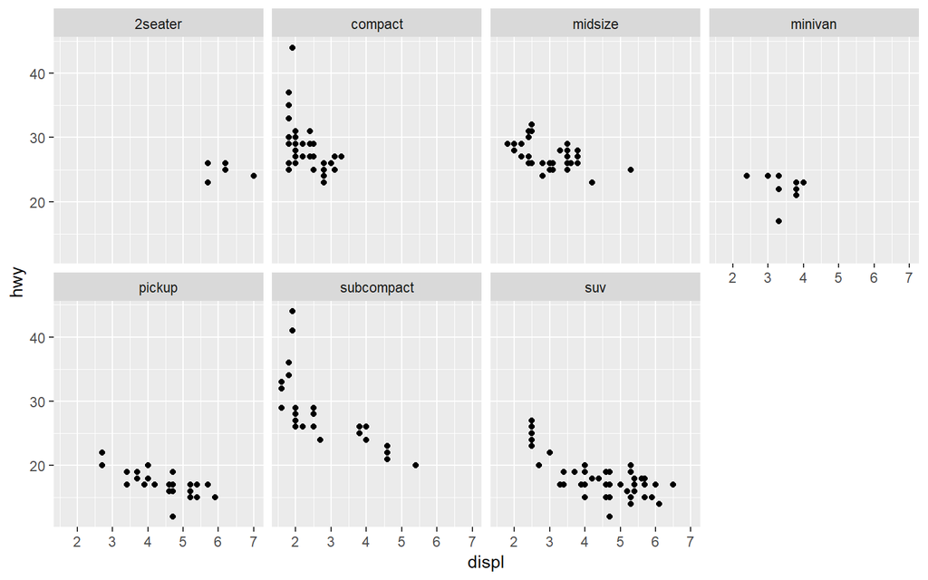

```r
ggplot(data = mpg) +
  geom_point(mapping = aes(x = displ, y = hwy)) +
  facet_wrap(~ class, nrow = 2)
```

facetting을 사용하면 각 그룹이 서로 겹치지 않는다. 그룹들이 많이 겹칠때는 유용하지만 약간의 차이를 보기가 힘들다. colour나 shape, size로 그룹들을 구분한다면 반대로 약간의 차이는 보기 쉽다.

facet간 비교는 annotation을 사용하면 좋다. 또는 각 패널의 배경에 모든 데이터를 그려 놓는 것이다.

5. Read ?facet_wrap. What does nrow do? What does ncol do? What other options control the layout of the individual panels? Why doesn’t facet_grid() have nrow and ncol variables?

*. `sacles = "free_x", scales = "free_y", scales = "free"` 또는 `scales = "fixed"`

free scales은 다른 스케일로 측정된 다수의 시계열을 나타내고자 할 때 유용하다.

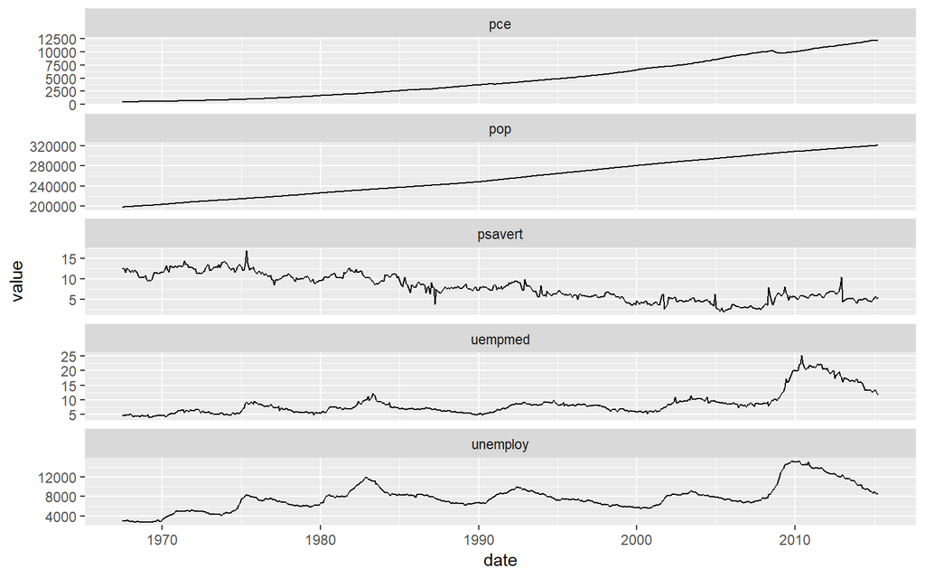

```r
ggplot(economics_long, aes(date, value))  +
  geom_line() +
  facet_wrap(~variable, ncol = 1, scales = "free_y")
```

- `facet_grid(space = "free")`

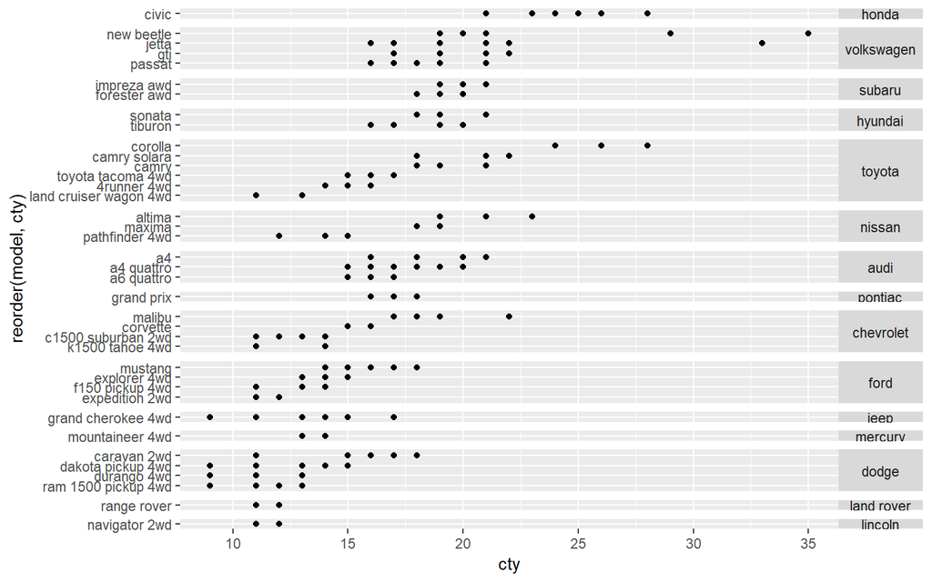

```r
ggplot(mpg, aes(cty, reorder(model, cty))) +
  geom_point() +
  facet_grid(reorder(manufacturer, -cty) ~ ., space = "free", scales = "free") +
  theme(strip.text.y = element_text(angle = 0))
```

6. When using facet_grid() you should usually put the variable with more unique levels in the columns. Why?

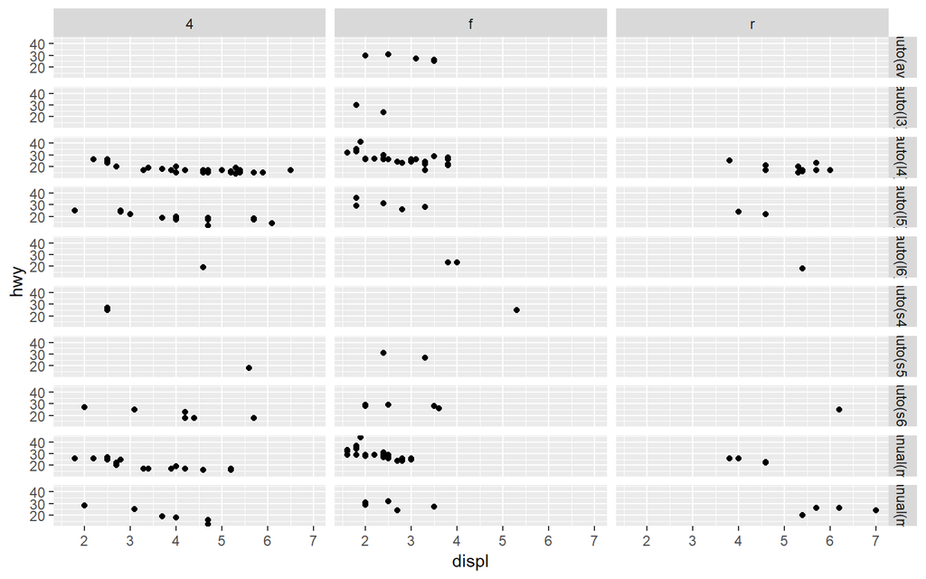

```r
ggplot(data = mpg) +
  geom_point(mapping = aes(x = displ, y = hwy)) +
  facet_grid(trans ~ drv)
```

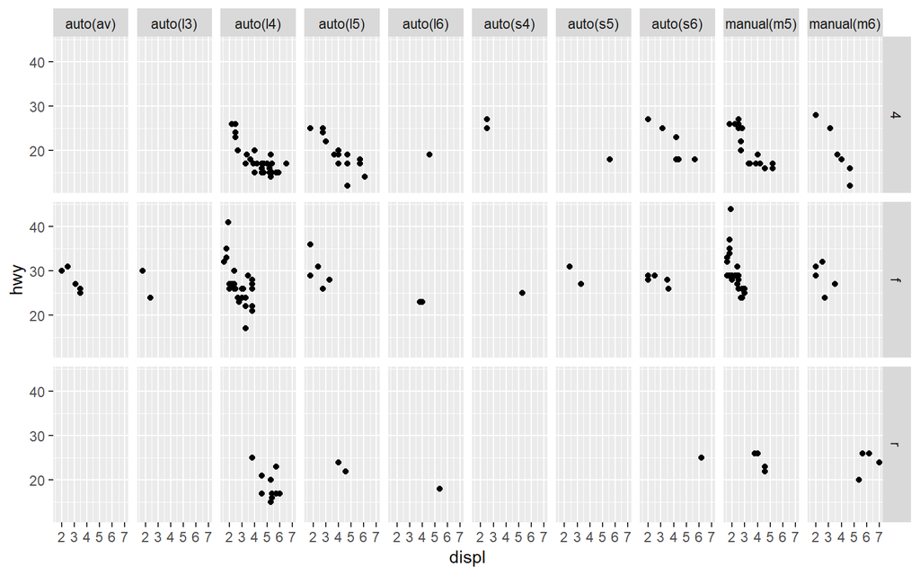

```r
ggplot(data = mpg) +
  geom_point(mapping = aes(x = displ, y = hwy)) +
  facet_grid(drv ~ trans)
```

패널 이름이 좀 더 보기 쉽다. 또한, 일반적으로 모니터는 좌우로 길다.

연속형 변수를 facet하기 위해 이산화 해야한다.

- cut_interval(x, n) : 데이터를 같은 길이의 n개의 구간으로 나눈다.
- cut_width(x, width) : 데이터를 너비로 나눈다.
- cut_number(x, n = 10) : 데이터를 같은 수의 점을 포함하는 n개의 구간으로 나눈다.

## 1.2 Statistical Transformations

`group="whatever"` is a “dummy” grouping to override the default behavior, which (here) is to group by `cut` and in general is to group by the x variable. The default for `geom_bar` is to group by the x variable in order to separately count the number of rows in each level of the x variable. For example, here, the default would be for `geom_bar` to return the number of rows with `cut` equal to “Fair”, “Good”, etc.

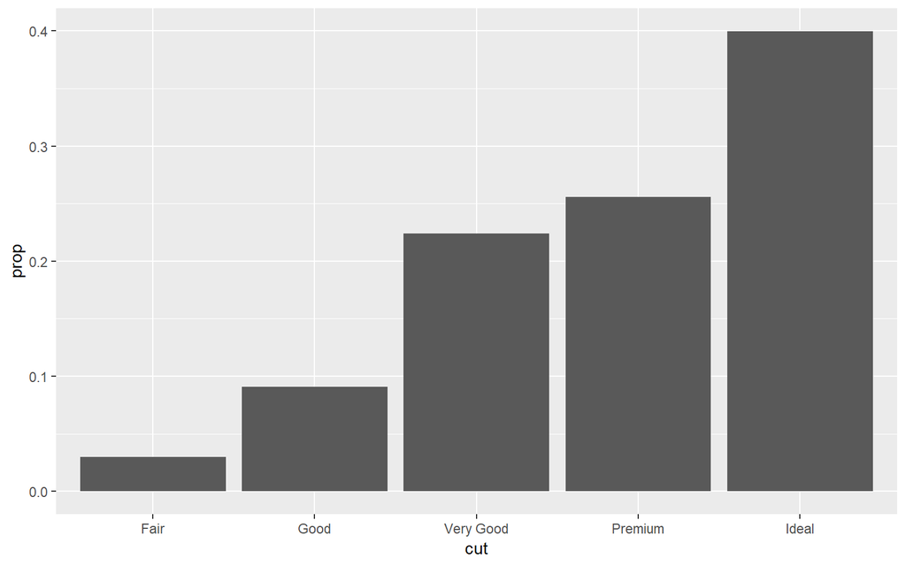

```r
ggplot(diamonds) +
  geom_bar(aes(cut, ..prop.., group = 1))
```

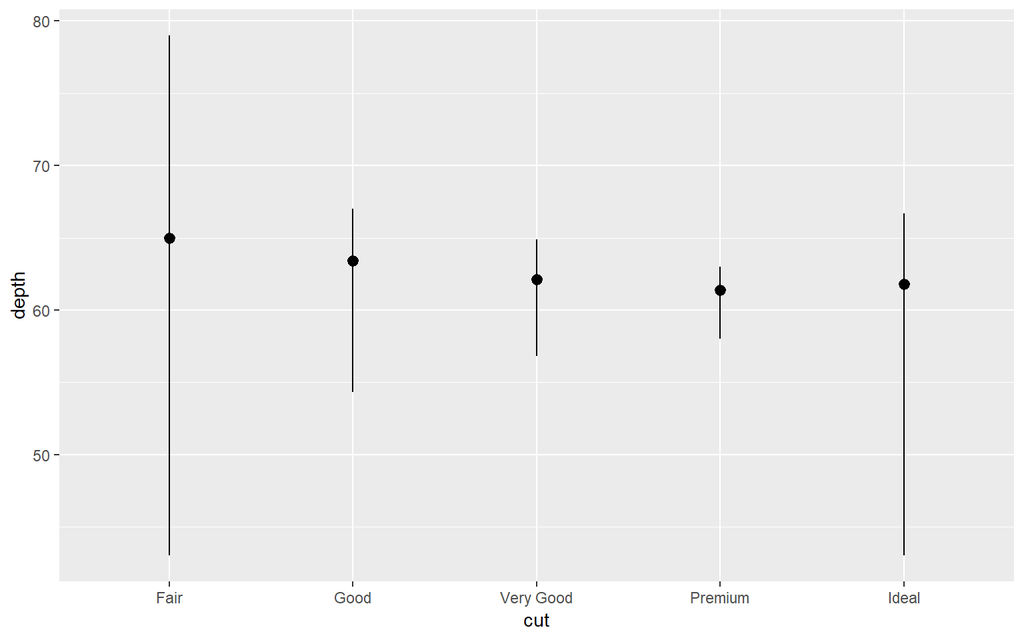

```r
ggplot(diamonds) +
  stat_summary(
    aes(cut, depth),
    fun.ymin = min,
    fun.ymax = max,
    fun.y = median
  )
```

## 1.3 Exercises

In our proportion bar chart, we need to set group = 1. Why? In other words what is the problem with these two graphs?

```r
ggplot(data = diamonds) +
  geom_bar(mapping = aes(x = cut, y = ..prop..))
ggplot(data = diamonds) +
  geom_bar(
    mapping = aes(x = cut, fill = color, y = ..prop..)
  )
```

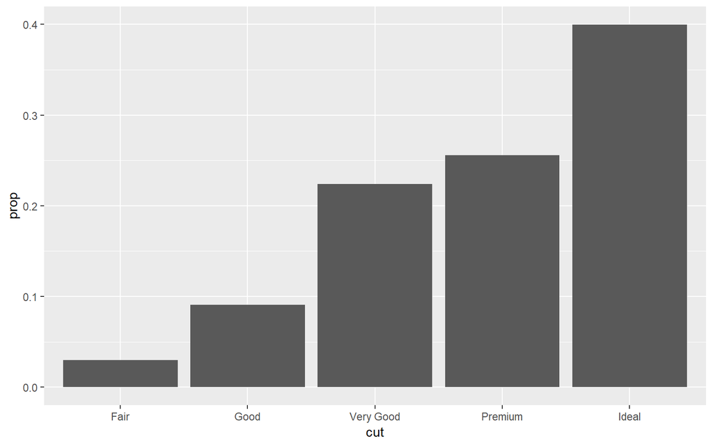

```r
ggplot(data = diamonds) +
  geom_bar(mapping = aes(x = cut, y = ..prop.., group = 1))
```

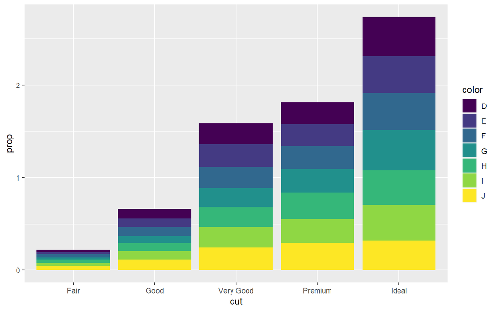

```r
ggplot(data = diamonds) +
  geom_bar(
    mapping = aes(x = cut, fill = color, y = ..prop.., group = color)
  )
```

## 1.4 Position Adjustments

- `position = "fill"` 그룹별 비율을 비교하기에 좋다.

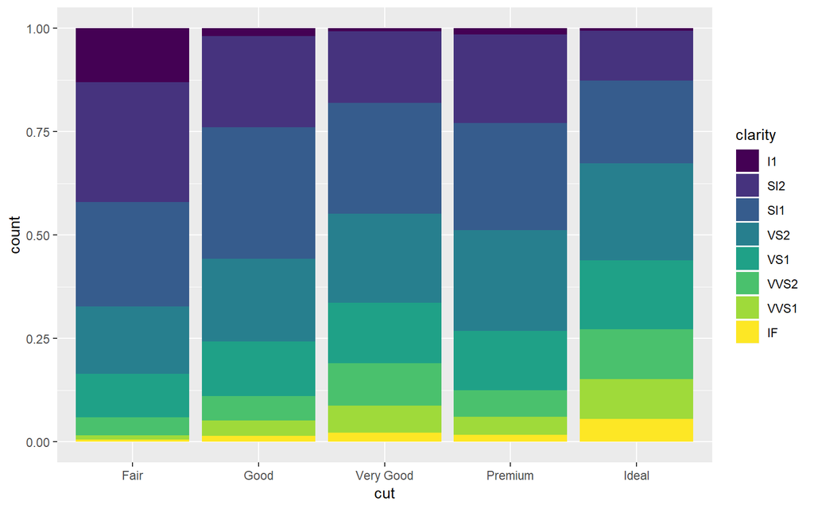

```r
ggplot(data = diamonds) +
  geom_bar(
    mapping = aes(x = cut, fill = clarity),
    position = "fill"
  )
```

- `position = "dodge"` 개별 값을 비교하기 좋다.

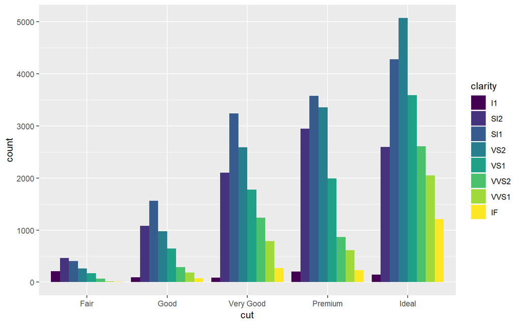

```r
ggplot(data = diamonds) +
  geom_bar(
    mapping = aes(x = cut, fill = clarity),
    position = "dodge"
  )
```

## 1.5 Coordinate Systems

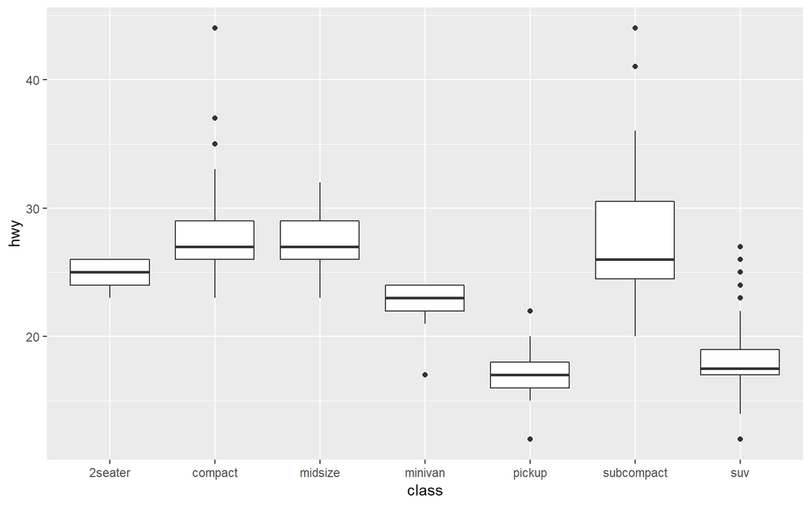

```r
ggplot(data = mpg, mapping = aes(x = class, y = hwy)) +
  geom_boxplot()
```

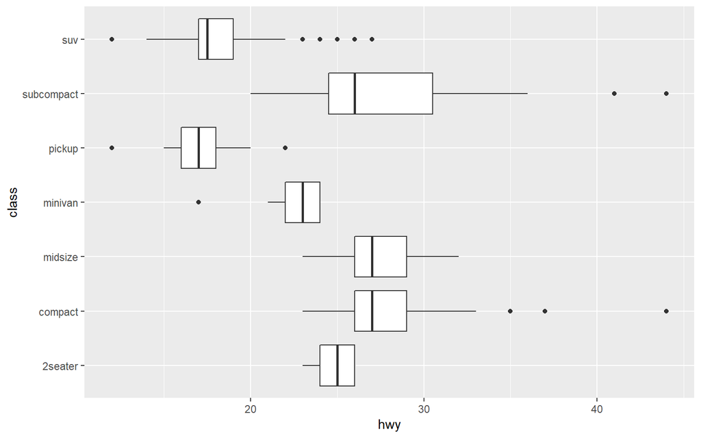

```r
ggplot(data = mpg, mapping = aes(x = class, y = hwy)) +
  geom_boxplot() +
  coord_flip()
```

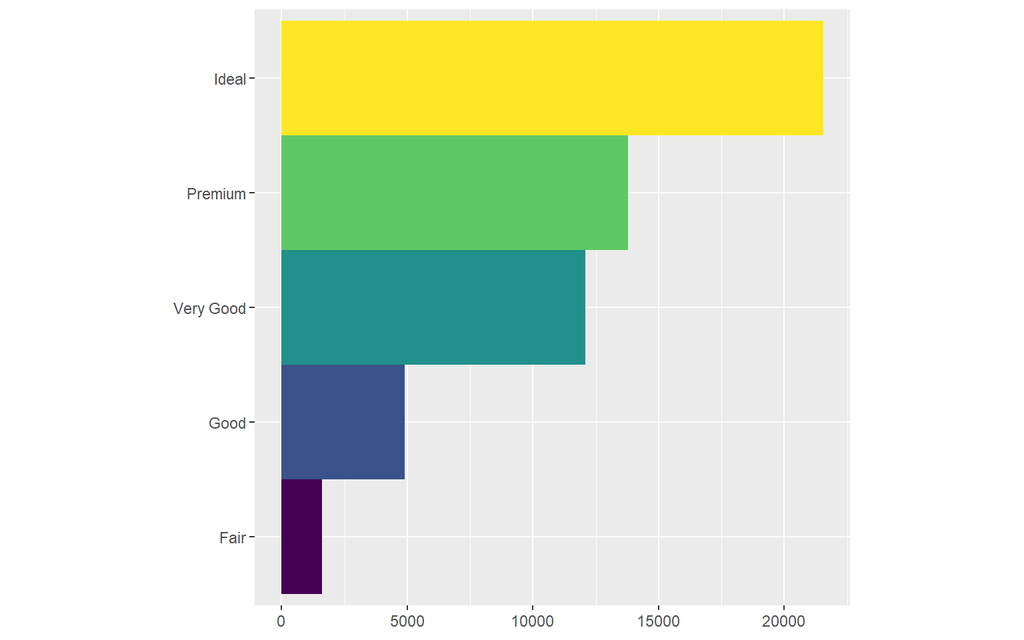

```r
bar <- ggplot(data = diamonds) +
  geom_bar(
    mapping = aes(x = cut, fill = cut),
    show.legend = FALSE,
    width = 1
  ) +
  theme(aspect.ratio = 1) + # 패널의 가로세로 비율을 1
  labs(x = NULL, y = NULL)
bar + coord_flip()
```

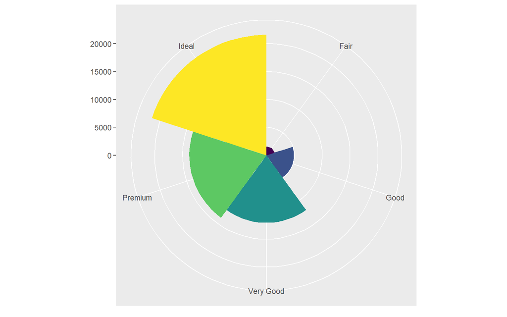

```r
bar + coord_polar()
```

What does the following plot tell you about the relationship between city and highway mpg? Whyiscoord_fixed() important? What does geom_abline() do?

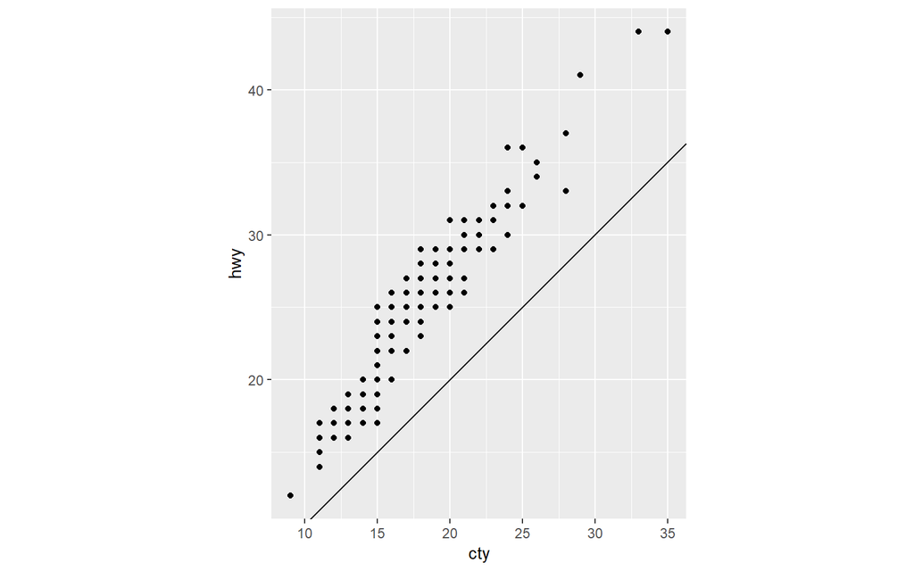

```r
ggplot(data = mpg, mapping = aes(x = cty, y = hwy)) +
  geom_point() +
  geom_abline() +
  coord_fixed() # 가로의 단위의 길이와 세로의 단위의 길이가 정확히 일치
```